# Intelligence Artificielle

Collège Clavin - Informatique

Julien Ribon

# Discussion sur l’IA

## Questions sur l’IA et l’apprentissage

### “Pour ou contre l’apprentissage de/avec l’IA ?”

Axes de discussion possibles :

- Impact sur l’apprentissage et le cerveau
- Sécurité des données et confidentialité
- Propriété intellectuelle & droits d’auteurs
- Monde du travail et emplois
- Gestion de l’énergie et émission de CO2
- Utilisation responsable et éthique
- Souveraineté numérique
- Droits

## Méthode Jigsaw

Effectue une analyse SWOT sur l’utilisation de l’IA.

1. **Groupes de base (3-4 personnes)** : lecture d’articles
2. **Groupes experts par catégorie S-W-O-T** : carte mentale
3. **Retour dans les groupes de base** : slides & matrice SWOT
4. **Présentations par groupe** (5-7min/groupe)
5. **Debriefing & conclusion**

## Analyse SWOT

L’analyse SWOT est une méthode d’évaluation stratégique qui permet d’identifier :

- les **Points Forts** (Strengths),
- les **Faiblesses** (Weaknesses),
- les **Opportunités** (Opportunities) et
- les **Menaces** (Threats)

liés à un sujet ou projet donné. Elle permet de dresser un état des lieux et de structurer la réflexion.

## Matrice SWOT

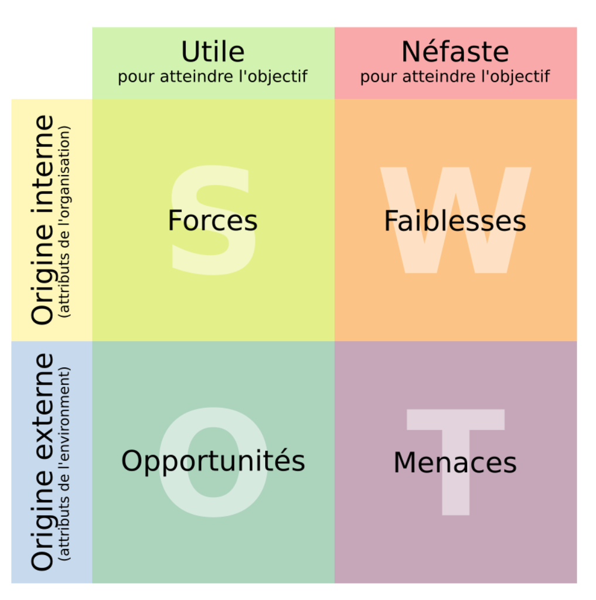

## Phase 1 : Groupes de base (10-15min)

- Formation des groupes de travail (3-4 personnes)
- Ecrire sur 2 post-it : 1 attente & 1 crainte par rapport à l’IA
- Se répartir les catégories SWOT entre membre du groupe.
- Lire le texte correspondants à sa catégorie

## Phase 2 : Groupes experts par catégorie (10-15min)

- Quitter son groupe de base et se regrouper entre experts
- Chaque personne présente ses idées, notes, etc.
- Récolte et organisation des points (forces, faiblesses, opportunités, menaces) en une **carte mentale**

**A faire**: dessiner une **carte mentale** représentant les points clés de l’article.

## Phase 2 : Carte mentale (mindmap)

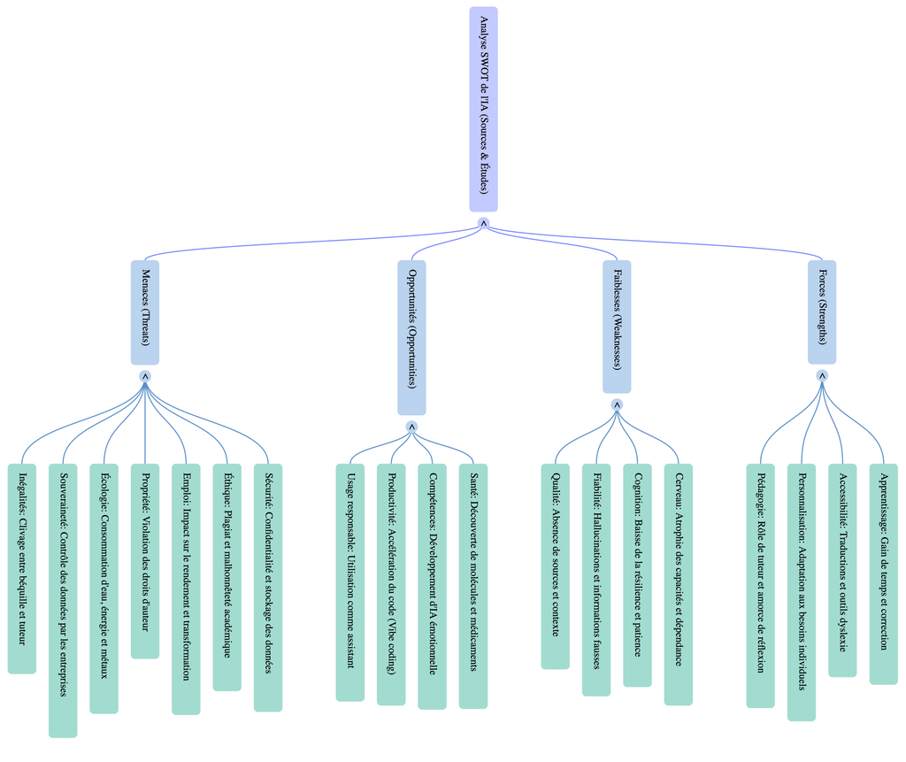

## Phase 3 : Retour dans les groupes de bases (10-15min)

- Attribuer les rôles: présentateur, facilitateur, secrétaire.
- Débrifer et discuter des différents élément obtenu.
- Chacun présent les points récolté en groupes d’experts.
- Créer une matrice SWOT sur l’utilisation de l’IA (min. 3 arguments/case dont 1 lié à l’enseignement)
- Préparer une présentation de 5-6 diapositives
- Déposer la présentation sur Moodle.

## Phase 4 : Présentation des résultats

- Chaque groupe présente ses résultats devant la classe (5min/groupe)
- Question & réponse (2min/groupe)
- Discussion globale et comparaison de tous les arguments.
- Synthèse sur les enjeux de l’IA

# Impacts de l’IA sur l’apprentissage

## Illusion de maîtrise & nécessité de la pensée critique

- Illusion de maîtrise chez les étudiant (“feeling of knowing”)
- Utilisation passive de l’IA
- Manque d’effort cognitif

## Illusion de maîtrise

L’illusion de maîtrise chez les étudiants utilisant l’IA générative

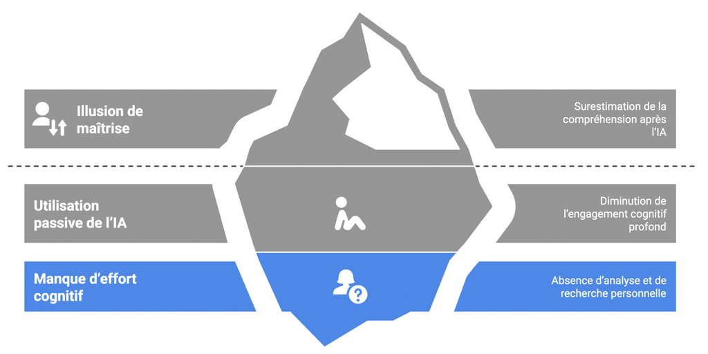

## Illusion de maîtrise & nécessité de la pensée critique

Processus où l’IA pourrait poser problème :

- L’analyse critique des sources (verifier les sources)
- La structuration de la pensée argumentée (réponse clé en main)
- La réflexion métacognitive sur l’apprentissage (comment puis-je m’améliorer?)
- Le danger est de confondre “réponse obtenue” et “savoir acquis”!

## Illusion de maîtrise

L’IA entrave la pensée critique des étudiant-e•s

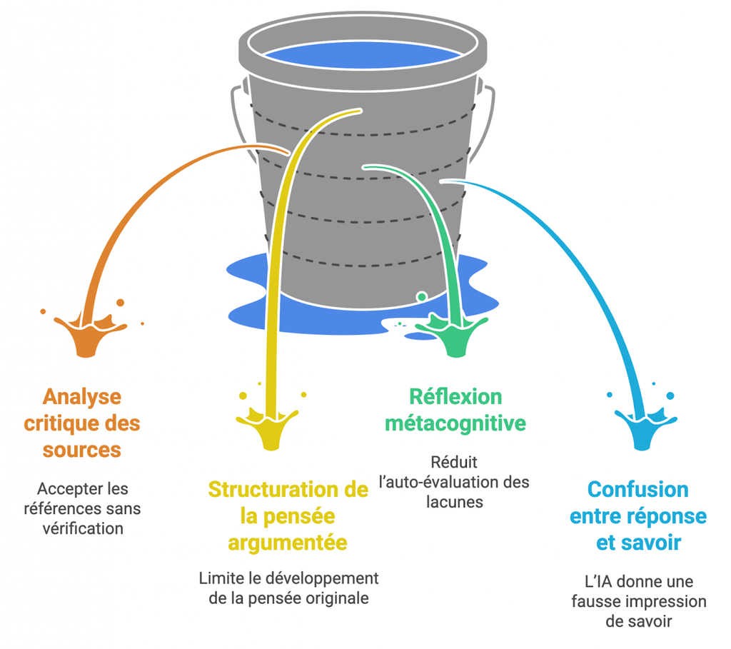

## IA comme outil d’accompagnement pédagogique (tuteur virtuel)

IA génératives peut offrir une forme d’assistance, mais :

- Anthropomorphisation et dépendance émotionnelle (prêter des intentions ou une intelligence à une IA)
- Réduction des interactions humaines (moins solliciter l’enseignant ou ses camarades)
- Baisse de la tolérance à la frustration (réponses immédiates)
- Disparition du conflit cognitif (IA évite la contradiction)

Tuteur IA a utiliser comme complément (pas comme substitut).

## IA comme tuteur virtuel

Dépendance émotionnelle envers l’IA chez les élèves.

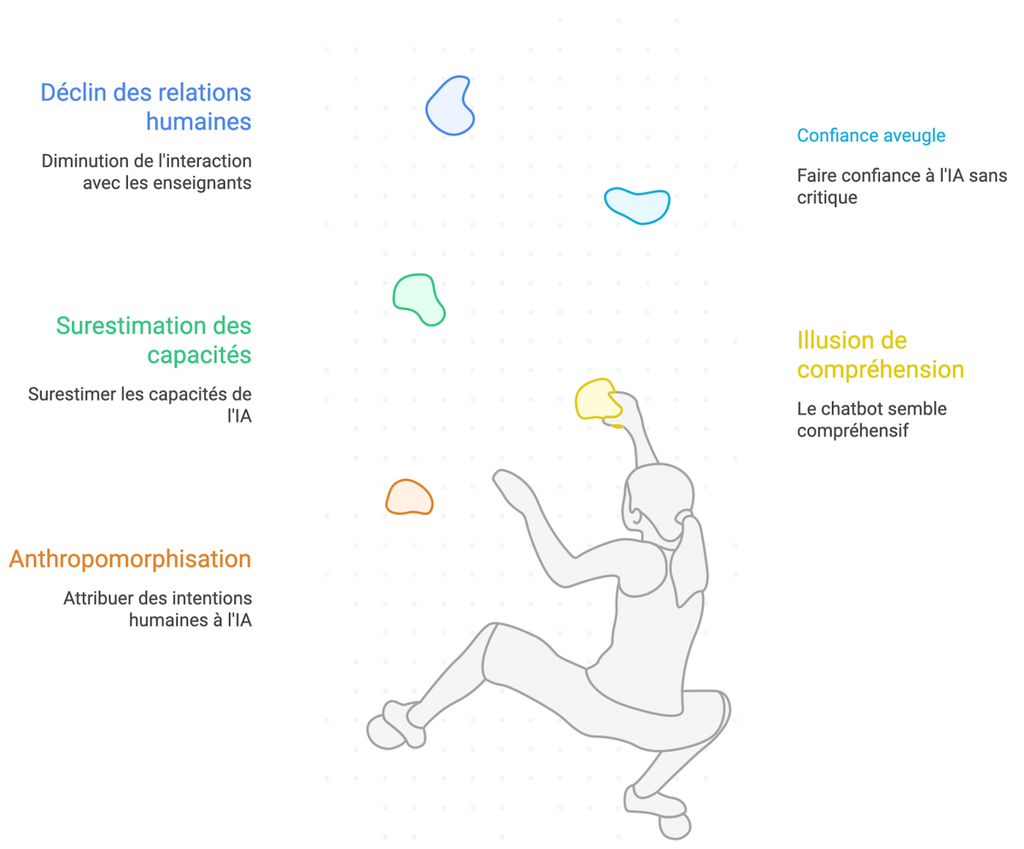

## Analyse SWOT de l’IA

IA comme outil d’accompagnement pédagogique

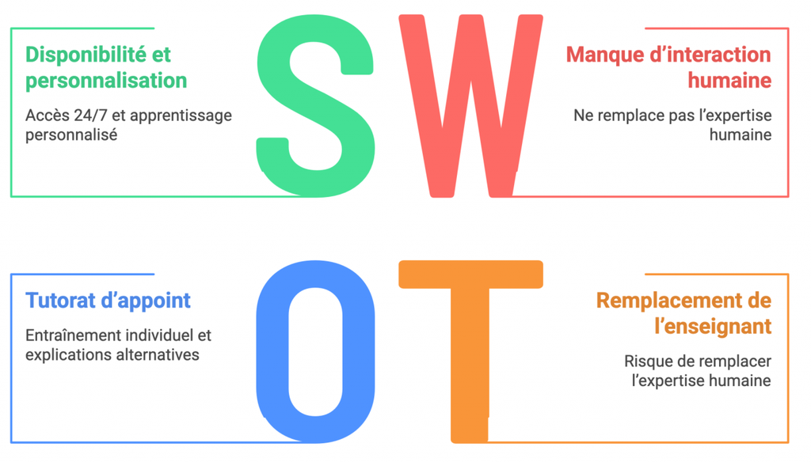

## IA et production scolaire : assistance ou substitution

- Risques cognitifs et “délégation” du travail intellectuel (gain de temps vs perte d’opportunité d’apprendre)
- Passivité intellectuelle et non-intériorisation des savoirs.
- Perte de l’entraînement de compétences fondamentales (IA = raccourci cognitif)
- La “fabrique du plausible” et le risque d’erreurs non détectées (vraisemblance)
- Atteinte à l’intégrité de l’apprentissage

## IA et production scolaire

Usages légitimes vs. problèmatiques (frontère floue).

Types d’usage :

- **Instrumental**: IA utilisé comme outil technique (correcteur de grammaire)
- **Consultatif**: stimuler les idées sans se substituer à l’auteur (“sparing-partner”)
- **Contributif**: IA collabore et génère une part significative du contenu (doit être préciser si autorisé)
- **Substitutif**: l’IA est le producteur principal du travail.

## Usage de l’IA dans le travail scolaire

De l’outil à la substitution…

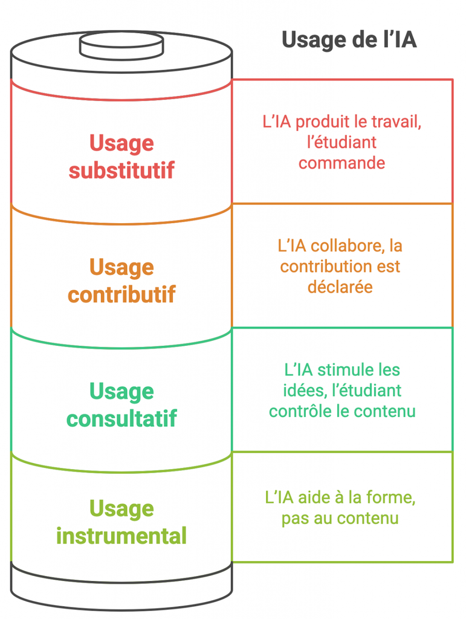

## IA et production scolaire

L’important est de poser explicitement les limites dans chaque contexte (chaque cours, chaque institution) :

*Qu’est-ce qui est permis? Qu’est-ce qui ne l’est pas?*

Exemples :

*«Utiliser ChatGPT pour vous aider à trouver des idées (usage consultatif), mais réécrit avec vos mots et interdit de le laisser tel quel (pas d’usage substitutif). »*

*Sous condition de joindre en annexe le brouillon sorti de l’IA et d’écrire une réflexion sur comment l’IA a été utilisée.*

## Références

L’IA à l’Université de Lausanne

[Impacts de l’IA sur l’apprentissage et l’enseignement : Entre soutien et illusion](https://wp.unil.ch/iaunil/impacts-de-lia-sur-lapprentissage-et-lenseignement/)